# Inequalities in Jail & Prison Populations in the U.S.

Cade Jeong

2022-11-17

## Abstract

With the ever increasing population in prison and the rate of incarceration in America, we are greatly concerned about the life of those behind bars and the possible racial disparities that exist regarding the population in prison. Our goal is to find where these disparities exist using data and suggest ways to fix them.

## Introduction

Ever since 1865 with the end of the Civil War and the passage of the 13th Amendment, the incarceration and arrests had been a major issue to those who are Black and/or not privileged. And as if to follow the historical trend, newly elected officials and policymaker did not step up to address the issues at hand but rather, caused more suffering. Although the idea of racial disparities within the jail population is a big issue itself, within the context that the U.S. holds 16% of the jail population in the entire world is more troublesome. As quoted from [Vera Institute](https://www.vera.org/), “From 1850 to 1940, racial and ethnic minorities—including foreign-born and non-English speaking European immigrants—made up 40 to 50 percent of the prison population. In 2015, about 55 percent of people imprisoned in federal or state prisons were Black or Latino.” The dataset is collected so that we can analyze the patterns in which inequalities exist and suggest possible solutions to how they can be fixed. Which makes the direct stakeholders for this dataset and its usage being policymakers, families (including self) of those being incarcerated, researchers (data), and indirect being all those who belong in the privilege hazard; not knowing about what is going on.

## Data Summary

I am not sure if we were supposed to answer exactly the three questions that are on Canvas or we could choose our data like the P2, but while looking at the data set and reading through its code book, I got my interest on looking into which race faced the most inequalities in being prisoned. And before mentioning the specific summarized data, the data set is said to contain data from 1970 to 2018, however, in order to calculate including every states’ data, the max year used in this summarization was 2016.

In the year 1970, the race holding the majority of population in the U.S. was black_prison_rate. Which means that the Black population held the majority in prison. And the opposite goes to aapi_prison_rate. Moving onto year 2016, the race holding the majority of population in the U.S. was white_prison_rate. Which means that the White population held the majority in prison but not by much. Black_prison_rate was coming in second very closely to the White. And the least goes to aapi_prison_rate.

This being said, we can see that AAPI race were always the least likely to be a prisoner as they had the smallest population in the early days and recent. However, we can definitely see that Black population has been and always been a majority (although in year 2016, White population was larger but noy by much).

Based on this trend, we can see that the Black population has been suffering from the inequalities over the years in the U.S. and to add more detailed information on this, I found that 2013 was the year in which Black population was at large in prison in the U.S. with the population of 501,201 and that CA is the state in which Black population is at large in prison with the population at 1,281,008.

### Chart 1: Increase of Jail Population in the U.S. (1970 - 2018)

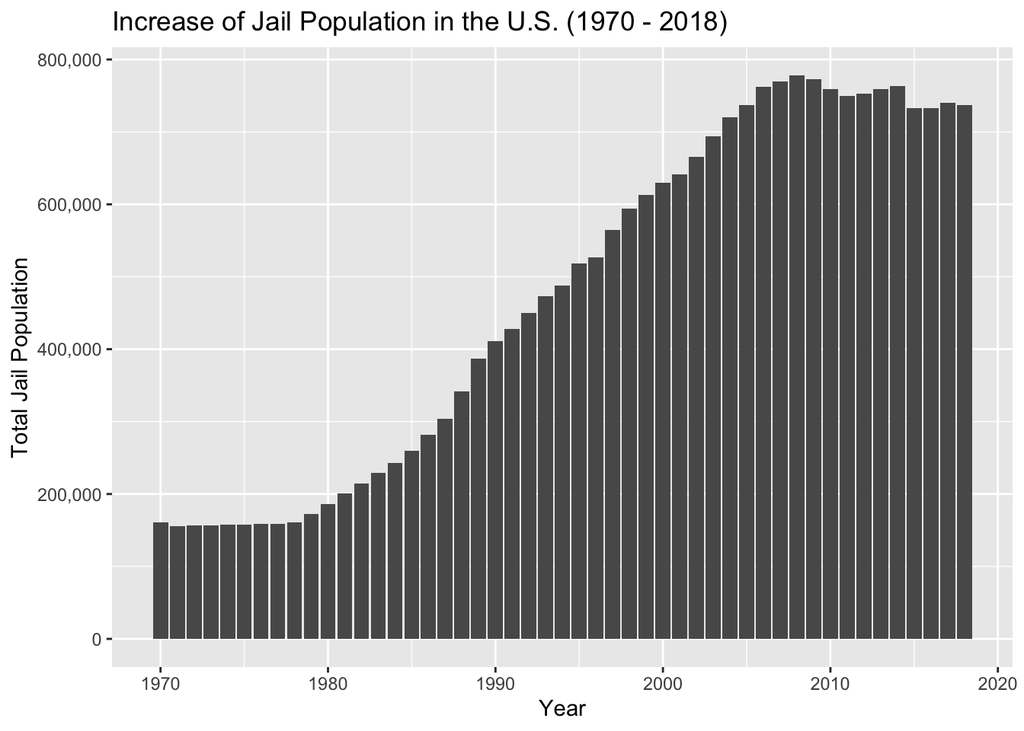

#### How did the jail population in the U.S. change over time?

This plot shows us that the general trend of jail population in the U.S. through out the years has increased. 1970 had its peak during the 1970s, slowed down until around 1979 and then started to increase until around 2010. The numbers almost quadrupled in the last 50 years.

### Chart 2: Increase of Jail Population by states (1970 - 2018)

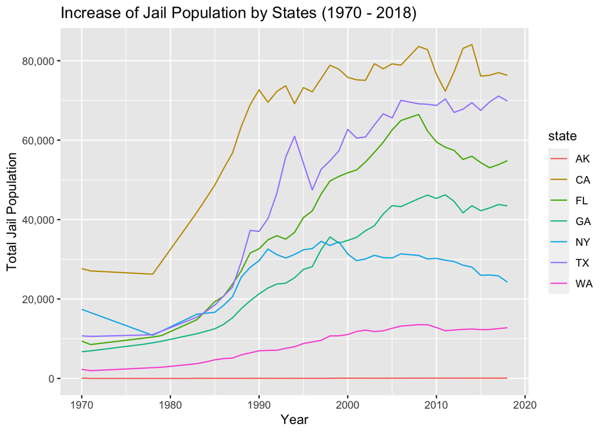

### Chart 3: Ratio of Incarceration for Black Population Based on Urbanicty

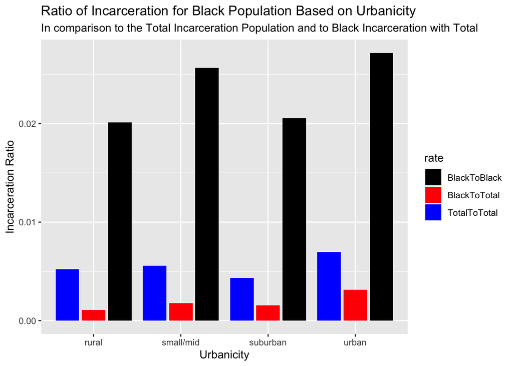

#### How is the Black population experiencing inequalities based on urbanicity of the U.S.?

Taking a good look at this plot, we can see that BlackToBlack is a ratio that was calculated based on Black population by the urbanicity to how many were incarcerated. Thankfully it wasn’t too high. However, not comparing it to the BlackToTotal and TotalToTotal, we can see in urban area, that Black incarceration population takes almost half of the total incarceration.

### Chart 4: Incarcerated Population Ratio of Balck to White by Counties in WA (1970 - 2018)

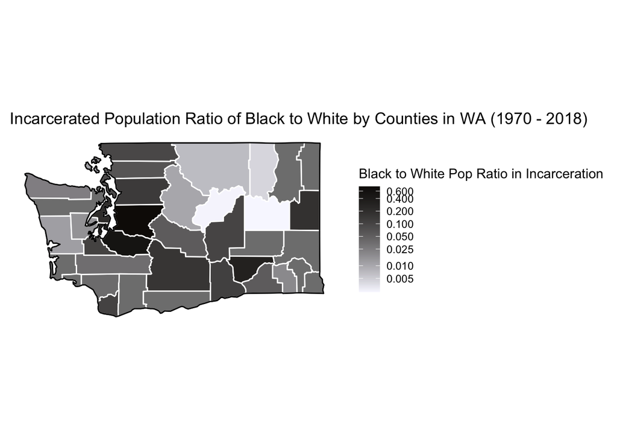

#### How does the difference counties in WA vary in their Black to White incarceration population?

This map allows us to take a look at the Washington state by counties and how and where exactly the inequalities are more existent. Based on what I know, we can see that in the King county, there seems to be a good number of Black incarcerated population in comparison to the White. In some of areas near Spokane, and such, there seems to be less Black incarcerated populations to White. Darker the area, more Black incarcerated populations there are in comparison to White incarcerated population.